# Risk Factor Analysis

## Outcome Variable

**Outcome Variable:** stunted

## Predictor Variables

**Intervention Variable:** lag_WHZ_quart

**Adjustment Set:**

unadjusted

## Stratifying Variables

The analysis was stratified on these variable(s):

- agecat
- studyid
- country

## Data Summary

| agecat | studyid | country | lag_WHZ_quart | stunted | n_cell | n |
| --- | --- | --- | --- | --- | --- | --- |
| 12 months | ki0047075b-MAL-ED | BANGLADESH | 1 | 0 | 12 | 230 |
| 12 months | ki0047075b-MAL-ED | BANGLADESH | 1 | 1 | 14 | 230 |
| 12 months | ki0047075b-MAL-ED | BANGLADESH | 2 | 0 | 56 | 230 |
| 12 months | ki0047075b-MAL-ED | BANGLADESH | 2 | 1 | 35 | 230 |
| 12 months | ki0047075b-MAL-ED | BANGLADESH | 3 | 0 | 63 | 230 |
| 12 months | ki0047075b-MAL-ED | BANGLADESH | 3 | 1 | 26 | 230 |
| 12 months | ki0047075b-MAL-ED | BANGLADESH | 4 | 0 | 21 | 230 |
| 12 months | ki0047075b-MAL-ED | BANGLADESH | 4 | 1 | 3 | 230 |
| 12 months | ki0047075b-MAL-ED | BRAZIL | 1 | 0 | 24 | 194 |
| 12 months | ki0047075b-MAL-ED | BRAZIL | 1 | 1 | 1 | 194 |
| 12 months | ki0047075b-MAL-ED | BRAZIL | 2 | 0 | 59 | 194 |
| 12 months | ki0047075b-MAL-ED | BRAZIL | 2 | 1 | 3 | 194 |
| 12 months | ki0047075b-MAL-ED | BRAZIL | 3 | 0 | 75 | 194 |
| 12 months | ki0047075b-MAL-ED | BRAZIL | 3 | 1 | 3 | 194 |
| 12 months | ki0047075b-MAL-ED | BRAZIL | 4 | 0 | 28 | 194 |
| 12 months | ki0047075b-MAL-ED | BRAZIL | 4 | 1 | 1 | 194 |
| 12 months | ki0047075b-MAL-ED | INDIA | 1 | 0 | 85 | 228 |
| 12 months | ki0047075b-MAL-ED | INDIA | 1 | 1 | 50 | 228 |
| 12 months | ki0047075b-MAL-ED | INDIA | 2 | 0 | 51 | 228 |
| 12 months | ki0047075b-MAL-ED | INDIA | 2 | 1 | 16 | 228 |
| 12 months | ki0047075b-MAL-ED | INDIA | 3 | 0 | 15 | 228 |
| 12 months | ki0047075b-MAL-ED | INDIA | 3 | 1 | 5 | 228 |
| 12 months | ki0047075b-MAL-ED | INDIA | 4 | 0 | 5 | 228 |
| 12 months | ki0047075b-MAL-ED | INDIA | 4 | 1 | 1 | 228 |
| 12 months | ki0047075b-MAL-ED | NEPAL | 1 | 0 | 62 | 231 |
| 12 months | ki0047075b-MAL-ED | NEPAL | 1 | 1 | 8 | 231 |
| 12 months | ki0047075b-MAL-ED | NEPAL | 2 | 0 | 81 | 231 |
| 12 months | ki0047075b-MAL-ED | NEPAL | 2 | 1 | 11 | 231 |
| 12 months | ki0047075b-MAL-ED | NEPAL | 3 | 0 | 54 | 231 |
| 12 months | ki0047075b-MAL-ED | NEPAL | 3 | 1 | 4 | 231 |

[output cut: 874 more lines]

The following strata were considered:

- agecat: 12 months, studyid: ki0047075b-MAL-ED, country: BANGLADESH
- agecat: 12 months, studyid: ki0047075b-MAL-ED, country: BRAZIL
- agecat: 12 months, studyid: ki0047075b-MAL-ED, country: INDIA
- agecat: 12 months, studyid: ki0047075b-MAL-ED, country: NEPAL
- agecat: 12 months, studyid: ki0047075b-MAL-ED, country: PERU
- agecat: 12 months, studyid: ki0047075b-MAL-ED, country: SOUTH AFRICA
- agecat: 12 months, studyid: ki0047075b-MAL-ED, country: TANZANIA, UNITED REPUBLIC OF
- agecat: 12 months, studyid: ki1000108-CMC-V-BCS-2002, country: INDIA
- agecat: 12 months, studyid: ki1000108-IRC, country: INDIA
- agecat: 12 months, studyid: ki1000109-EE, country: PAKISTAN
- agecat: 12 months, studyid: ki1017093b-PROVIDE, country: BANGLADESH
- agecat: 12 months, studyid: ki1066203-TanzaniaChild2, country: TANZANIA, UNITED REPUBLIC OF
- agecat: 12 months, studyid: ki1101329-Keneba, country: GAMBIA
- agecat: 12 months, studyid: ki1112895-Guatemala BSC, country: GUATEMALA
- agecat: 12 months, studyid: ki1113344-GMS-Nepal, country: NEPAL
- agecat: 12 months, studyid: ki1114097-CMIN, country: BANGLADESH
- agecat: 12 months, studyid: ki1114097-CMIN, country: PERU
- agecat: 15 months, studyid: ki0047075b-MAL-ED, country: BANGLADESH
- agecat: 15 months, studyid: ki0047075b-MAL-ED, country: BRAZIL
- agecat: 15 months, studyid: ki0047075b-MAL-ED, country: INDIA
- agecat: 15 months, studyid: ki0047075b-MAL-ED, country: NEPAL
- agecat: 15 months, studyid: ki0047075b-MAL-ED, country: PERU
- agecat: 15 months, studyid: ki0047075b-MAL-ED, country: SOUTH AFRICA
- agecat: 15 months, studyid: ki0047075b-MAL-ED, country: TANZANIA, UNITED REPUBLIC OF
- agecat: 15 months, studyid: ki1000108-CMC-V-BCS-2002, country: INDIA
- agecat: 15 months, studyid: ki1000108-IRC, country: INDIA
- agecat: 15 months, studyid: ki1000109-EE, country: PAKISTAN
- agecat: 15 months, studyid: ki1017093b-PROVIDE, country: BANGLADESH
- agecat: 15 months, studyid: ki1066203-TanzaniaChild2, country: TANZANIA, UNITED REPUBLIC OF
- agecat: 15 months, studyid: ki1101329-Keneba, country: GAMBIA
- agecat: 15 months, studyid: ki1112895-Guatemala BSC, country: GUATEMALA
- agecat: 15 months, studyid: ki1113344-GMS-Nepal, country: NEPAL
- agecat: 15 months, studyid: ki1114097-CMIN, country: BANGLADESH
- agecat: 15 months, studyid: ki1114097-CMIN, country: PERU
- agecat: 18 months, studyid: ki0047075b-MAL-ED, country: BANGLADESH
- agecat: 18 months, studyid: ki0047075b-MAL-ED, country: BRAZIL
- agecat: 18 months, studyid: ki0047075b-MAL-ED, country: INDIA
- agecat: 18 months, studyid: ki0047075b-MAL-ED, country: NEPAL
- agecat: 18 months, studyid: ki0047075b-MAL-ED, country: PERU
- agecat: 18 months, studyid: ki0047075b-MAL-ED, country: SOUTH AFRICA
- agecat: 18 months, studyid: ki0047075b-MAL-ED, country: TANZANIA, UNITED REPUBLIC OF
- agecat: 18 months, studyid: ki1000108-CMC-V-BCS-2002, country: INDIA
- agecat: 18 months, studyid: ki1000108-IRC, country: INDIA
- agecat: 18 months, studyid: ki1000109-EE, country: PAKISTAN
- agecat: 18 months, studyid: ki1017093b-PROVIDE, country: BANGLADESH
- agecat: 18 months, studyid: ki1066203-TanzaniaChild2, country: TANZANIA, UNITED REPUBLIC OF
- agecat: 18 months, studyid: ki1101329-Keneba, country: GAMBIA
- agecat: 18 months, studyid: ki1113344-GMS-Nepal, country: NEPAL
- agecat: 18 months, studyid: ki1114097-CMIN, country: BANGLADESH
- agecat: 18 months, studyid: ki1114097-CMIN, country: PERU
- agecat: 21 months, studyid: ki0047075b-MAL-ED, country: BANGLADESH
- agecat: 21 months, studyid: ki0047075b-MAL-ED, country: BRAZIL
- agecat: 21 months, studyid: ki0047075b-MAL-ED, country: INDIA
- agecat: 21 months, studyid: ki0047075b-MAL-ED, country: NEPAL
- agecat: 21 months, studyid: ki0047075b-MAL-ED, country: PERU
- agecat: 21 months, studyid: ki0047075b-MAL-ED, country: SOUTH AFRICA
- agecat: 21 months, studyid: ki0047075b-MAL-ED, country: TANZANIA, UNITED REPUBLIC OF
- agecat: 21 months, studyid: ki1000108-CMC-V-BCS-2002, country: INDIA
- agecat: 21 months, studyid: ki1000108-IRC, country: INDIA
- agecat: 21 months, studyid: ki1017093b-PROVIDE, country: BANGLADESH
- agecat: 21 months, studyid: ki1066203-TanzaniaChild2, country: TANZANIA, UNITED REPUBLIC OF
- agecat: 21 months, studyid: ki1101329-Keneba, country: GAMBIA
- agecat: 21 months, studyid: ki1113344-GMS-Nepal, country: NEPAL
- agecat: 21 months, studyid: ki1114097-CMIN, country: BANGLADESH
- agecat: 21 months, studyid: ki1114097-CMIN, country: PERU
- agecat: 3 months, studyid: ki0047075b-MAL-ED, country: BANGLADESH
- agecat: 3 months, studyid: ki0047075b-MAL-ED, country: BRAZIL
- agecat: 3 months, studyid: ki0047075b-MAL-ED, country: INDIA
- agecat: 3 months, studyid: ki0047075b-MAL-ED, country: NEPAL
- agecat: 3 months, studyid: ki0047075b-MAL-ED, country: PERU
- agecat: 3 months, studyid: ki0047075b-MAL-ED, country: SOUTH AFRICA
- agecat: 3 months, studyid: ki0047075b-MAL-ED, country: TANZANIA, UNITED REPUBLIC OF
- agecat: 3 months, studyid: ki1000108-CMC-V-BCS-2002, country: INDIA
- agecat: 3 months, studyid: ki1000108-IRC, country: INDIA
- agecat: 3 months, studyid: ki1000109-EE, country: PAKISTAN
- agecat: 3 months, studyid: ki1017093b-PROVIDE, country: BANGLADESH
- agecat: 3 months, studyid: ki1066203-TanzaniaChild2, country: TANZANIA, UNITED REPUBLIC OF
- agecat: 3 months, studyid: ki1101329-Keneba, country: GAMBIA
- agecat: 3 months, studyid: ki1114097-CMIN, country: BANGLADESH
- agecat: 3 months, studyid: ki1114097-CMIN, country: PERU
- agecat: 6 months, studyid: ki0047075b-MAL-ED, country: BANGLADESH
- agecat: 6 months, studyid: ki0047075b-MAL-ED, country: BRAZIL
- agecat: 6 months, studyid: ki0047075b-MAL-ED, country: INDIA
- agecat: 6 months, studyid: ki0047075b-MAL-ED, country: NEPAL
- agecat: 6 months, studyid: ki0047075b-MAL-ED, country: PERU
- agecat: 6 months, studyid: ki0047075b-MAL-ED, country: SOUTH AFRICA
- agecat: 6 months, studyid: ki0047075b-MAL-ED, country: TANZANIA, UNITED REPUBLIC OF
- agecat: 6 months, studyid: ki1000108-CMC-V-BCS-2002, country: INDIA
- agecat: 6 months, studyid: ki1000108-IRC, country: INDIA
- agecat: 6 months, studyid: ki1000109-EE, country: PAKISTAN
- agecat: 6 months, studyid: ki1017093b-PROVIDE, country: BANGLADESH
- agecat: 6 months, studyid: ki1066203-TanzaniaChild2, country: TANZANIA, UNITED REPUBLIC OF
- agecat: 6 months, studyid: ki1101329-Keneba, country: GAMBIA
- agecat: 6 months, studyid: ki1112895-Guatemala BSC, country: GUATEMALA
- agecat: 6 months, studyid: ki1114097-CMIN, country: BANGLADESH
- agecat: 6 months, studyid: ki1114097-CMIN, country: PERU
- agecat: 9 months, studyid: ki0047075b-MAL-ED, country: BANGLADESH
- agecat: 9 months, studyid: ki0047075b-MAL-ED, country: BRAZIL
- agecat: 9 months, studyid: ki0047075b-MAL-ED, country: INDIA
- agecat: 9 months, studyid: ki0047075b-MAL-ED, country: NEPAL
- agecat: 9 months, studyid: ki0047075b-MAL-ED, country: PERU
- agecat: 9 months, studyid: ki0047075b-MAL-ED, country: SOUTH AFRICA
- agecat: 9 months, studyid: ki0047075b-MAL-ED, country: TANZANIA, UNITED REPUBLIC OF
- agecat: 9 months, studyid: ki1000108-CMC-V-BCS-2002, country: INDIA
- agecat: 9 months, studyid: ki1000108-IRC, country: INDIA
- agecat: 9 months, studyid: ki1000109-EE, country: PAKISTAN
- agecat: 9 months, studyid: ki1017093b-PROVIDE, country: BANGLADESH
- agecat: 9 months, studyid: ki1066203-TanzaniaChild2, country: TANZANIA, UNITED REPUBLIC OF
- agecat: 9 months, studyid: ki1101329-Keneba, country: GAMBIA
- agecat: 9 months, studyid: ki1112895-Guatemala BSC, country: GUATEMALA
- agecat: 9 months, studyid: ki1113344-GMS-Nepal, country: NEPAL
- agecat: 9 months, studyid: ki1114097-CMIN, country: BANGLADESH
- agecat: 9 months, studyid: ki1114097-CMIN, country: PERU

### Dropped Strata

Some strata were dropped due to rare outcomes:

- agecat: 12 months, studyid: ki0047075b-MAL-ED, country: BANGLADESH
- agecat: 12 months, studyid: ki0047075b-MAL-ED, country: BRAZIL
- agecat: 12 months, studyid: ki0047075b-MAL-ED, country: INDIA
- agecat: 12 months, studyid: ki0047075b-MAL-ED, country: NEPAL
- agecat: 12 months, studyid: ki1000108-CMC-V-BCS-2002, country: INDIA
- agecat: 12 months, studyid: ki1000108-IRC, country: INDIA
- agecat: 12 months, studyid: ki1000109-EE, country: PAKISTAN
- agecat: 12 months, studyid: ki1113344-GMS-Nepal, country: NEPAL
- agecat: 15 months, studyid: ki0047075b-MAL-ED, country: BANGLADESH
- agecat: 15 months, studyid: ki0047075b-MAL-ED, country: BRAZIL
- agecat: 15 months, studyid: ki0047075b-MAL-ED, country: INDIA
- agecat: 15 months, studyid: ki0047075b-MAL-ED, country: NEPAL
- agecat: 15 months, studyid: ki1000108-CMC-V-BCS-2002, country: INDIA
- agecat: 15 months, studyid: ki1000108-IRC, country: INDIA
- agecat: 15 months, studyid: ki1000109-EE, country: PAKISTAN
- agecat: 15 months, studyid: ki1112895-Guatemala BSC, country: GUATEMALA
- agecat: 15 months, studyid: ki1113344-GMS-Nepal, country: NEPAL
- agecat: 18 months, studyid: ki0047075b-MAL-ED, country: BANGLADESH
- agecat: 18 months, studyid: ki0047075b-MAL-ED, country: BRAZIL
- agecat: 18 months, studyid: ki0047075b-MAL-ED, country: INDIA
- agecat: 18 months, studyid: ki0047075b-MAL-ED, country: NEPAL
- agecat: 18 months, studyid: ki0047075b-MAL-ED, country: TANZANIA, UNITED REPUBLIC OF
- agecat: 18 months, studyid: ki1000108-CMC-V-BCS-2002, country: INDIA
- agecat: 18 months, studyid: ki1000108-IRC, country: INDIA
- agecat: 18 months, studyid: ki1000109-EE, country: PAKISTAN
- agecat: 18 months, studyid: ki1113344-GMS-Nepal, country: NEPAL
- agecat: 18 months, studyid: ki1114097-CMIN, country: PERU
- agecat: 21 months, studyid: ki0047075b-MAL-ED, country: BANGLADESH
- agecat: 21 months, studyid: ki0047075b-MAL-ED, country: BRAZIL
- agecat: 21 months, studyid: ki0047075b-MAL-ED, country: INDIA
- agecat: 21 months, studyid: ki0047075b-MAL-ED, country: NEPAL
- agecat: 21 months, studyid: ki1000108-CMC-V-BCS-2002, country: INDIA
- agecat: 21 months, studyid: ki1000108-IRC, country: INDIA
- agecat: 21 months, studyid: ki1066203-TanzaniaChild2, country: TANZANIA, UNITED REPUBLIC OF
- agecat: 21 months, studyid: ki1113344-GMS-Nepal, country: NEPAL
- agecat: 21 months, studyid: ki1114097-CMIN, country: PERU
- agecat: 3 months, studyid: ki0047075b-MAL-ED, country: BANGLADESH
- agecat: 3 months, studyid: ki0047075b-MAL-ED, country: BRAZIL
- agecat: 3 months, studyid: ki0047075b-MAL-ED, country: INDIA
- agecat: 3 months, studyid: ki0047075b-MAL-ED, country: NEPAL
- agecat: 3 months, studyid: ki0047075b-MAL-ED, country: SOUTH AFRICA
- agecat: 3 months, studyid: ki0047075b-MAL-ED, country: TANZANIA, UNITED REPUBLIC OF
- agecat: 3 months, studyid: ki1000108-CMC-V-BCS-2002, country: INDIA
- agecat: 3 months, studyid: ki1000108-IRC, country: INDIA
- agecat: 3 months, studyid: ki1000109-EE, country: PAKISTAN
- agecat: 6 months, studyid: ki0047075b-MAL-ED, country: BANGLADESH
- agecat: 6 months, studyid: ki0047075b-MAL-ED, country: BRAZIL
- agecat: 6 months, studyid: ki0047075b-MAL-ED, country: INDIA
- agecat: 6 months, studyid: ki0047075b-MAL-ED, country: NEPAL
- agecat: 6 months, studyid: ki1000108-CMC-V-BCS-2002, country: INDIA
- agecat: 6 months, studyid: ki1000108-IRC, country: INDIA
- agecat: 6 months, studyid: ki1000109-EE, country: PAKISTAN
- agecat: 6 months, studyid: ki1017093b-PROVIDE, country: BANGLADESH
- agecat: 6 months, studyid: ki1114097-CMIN, country: PERU
- agecat: 9 months, studyid: ki0047075b-MAL-ED, country: BANGLADESH
- agecat: 9 months, studyid: ki0047075b-MAL-ED, country: BRAZIL
- agecat: 9 months, studyid: ki0047075b-MAL-ED, country: INDIA
- agecat: 9 months, studyid: ki0047075b-MAL-ED, country: NEPAL
- agecat: 9 months, studyid: ki1000108-CMC-V-BCS-2002, country: INDIA
- agecat: 9 months, studyid: ki1000108-IRC, country: INDIA
- agecat: 9 months, studyid: ki1000109-EE, country: PAKISTAN
- agecat: 9 months, studyid: ki1113344-GMS-Nepal, country: NEPAL

## Methods Detail

We’re interested in the causal parameters $E[Y_a]$ for all values of $a \in \mathcal{A}$. These parameters represent the mean outcome if, possibly contrary to fact, we intervened to set all units to have $A=a$. Under the randomization and positivity assumptions, these are identified by the statistical parameters $\psi_a=E_W[E_{Y|A,W}(Y|A=a,W)]$. In addition, we’re interested in the mean of $Y$, $E[Y]$ under no intervention (the observed mean). We will estimate these parameters by using SuperLearner to fit the relevant likelihood factors – $E_{Y|A,W}(Y|A=a,W)$ and $p(A=a|W)$, and then updating our likelihood fit using a joint TMLE.

For unadjusted analyses ($W=\{\}$), initial likelihoods were estimated using Lrnr_glm to estimate the simple $E(Y|A)$ and Lrnr_mean to estimate $p(A)$. For adjusted analyses, a small library containing Lrnr_glmnet, Lrnr_xgboost, and Lrnr_mean was used.

Having estimated these parameters, we will then use the delta method to estimate relative risks and attributable risks relative to a prespecified baseline level of $A$.

# Results Detail

## Results Plots

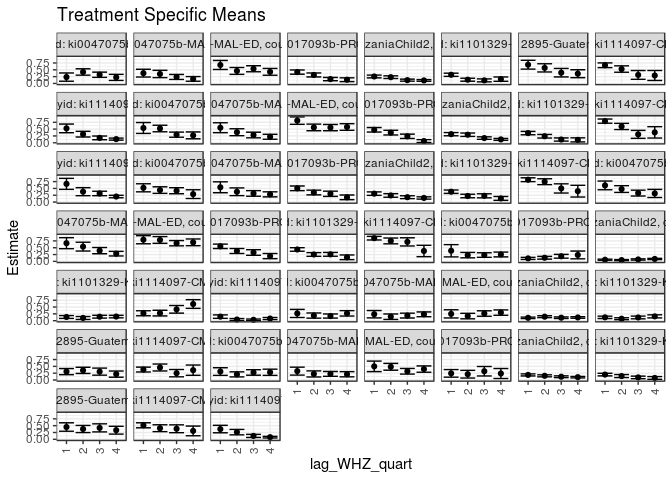

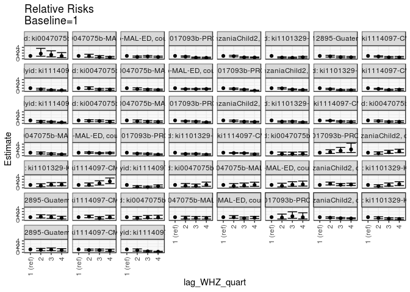

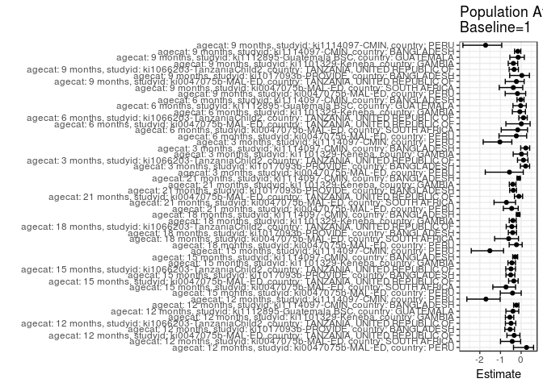

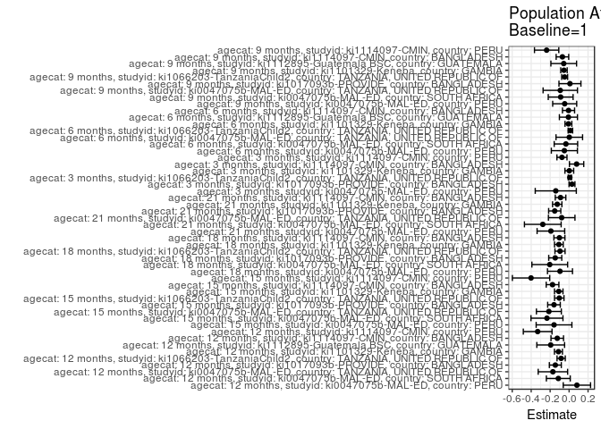

## Results Table

### Parameter: TSM

| agecat | studyid | country | intervention_level | baseline_level | estimate | ci_lower | ci_upper |
| --- | --- | --- | --- | --- | --- | --- | --- |
| 12 months | ki0047075b-MAL-ED | PERU | 1 | NA | 0.2333333 | 0.0816734 | 0.3849933 |
| 12 months | ki0047075b-MAL-ED | PERU | 2 | NA | 0.4202899 | 0.3035833 | 0.5369964 |
| 12 months | ki0047075b-MAL-ED | PERU | 3 | NA | 0.3186813 | 0.2227473 | 0.4146153 |
| 12 months | ki0047075b-MAL-ED | PERU | 4 | NA | 0.2222222 | 0.1111093 | 0.3333351 |
| 12 months | ki0047075b-MAL-ED | SOUTH AFRICA | 1 | NA | 0.3777778 | 0.2358383 | 0.5197172 |
| 12 months | ki0047075b-MAL-ED | SOUTH AFRICA | 2 | NA | 0.3469388 | 0.2133950 | 0.4804826 |
| 12 months | ki0047075b-MAL-ED | SOUTH AFRICA | 3 | NA | 0.2380952 | 0.1468302 | 0.3293603 |
| 12 months | ki0047075b-MAL-ED | SOUTH AFRICA | 4 | NA | 0.1666667 | 0.0804113 | 0.2529220 |
| 12 months | ki0047075b-MAL-ED | TANZANIA, UNITED REPUBLIC OF | 1 | NA | 0.6774194 | 0.5125055 | 0.8423333 |
| 12 months | ki0047075b-MAL-ED | TANZANIA, UNITED REPUBLIC OF | 2 | NA | 0.4590164 | 0.3336932 | 0.5843396 |
| 12 months | ki0047075b-MAL-ED | TANZANIA, UNITED REPUBLIC OF | 3 | NA | 0.5384615 | 0.4275890 | 0.6493341 |
| 12 months | ki0047075b-MAL-ED | TANZANIA, UNITED REPUBLIC OF | 4 | NA | 0.4262295 | 0.3018594 | 0.5505996 |
| 12 months | ki1017093b-PROVIDE | BANGLADESH | 1 | NA | 0.4166667 | 0.3392322 | 0.4941012 |
| 12 months | ki1017093b-PROVIDE | BANGLADESH | 2 | NA | 0.3116883 | 0.2384672 | 0.3849094 |
| 12 months | ki1017093b-PROVIDE | BANGLADESH | 3 | NA | 0.1597222 | 0.0998319 | 0.2196126 |
| 12 months | ki1017093b-PROVIDE | BANGLADESH | 4 | NA | 0.1368421 | 0.0676690 | 0.2060152 |
| 12 months | ki1066203-TanzaniaChild2 | TANZANIA, UNITED REPUBLIC OF | 1 | NA | 0.2553191 | 0.2044073 | 0.3062310 |
| 12 months | ki1066203-TanzaniaChild2 | TANZANIA, UNITED REPUBLIC OF | 2 | NA | 0.2299652 | 0.1812615 | 0.2786688 |
| 12 months | ki1066203-TanzaniaChild2 | TANZANIA, UNITED REPUBLIC OF | 3 | NA | 0.1212121 | 0.0840797 | 0.1583446 |
| 12 months | ki1066203-TanzaniaChild2 | TANZANIA, UNITED REPUBLIC OF | 4 | NA | 0.1111111 | 0.0811506 | 0.1410716 |
| 12 months | ki1101329-Keneba | GAMBIA | 1 | NA | 0.3179916 | 0.2589023 | 0.3770810 |
| 12 months | ki1101329-Keneba | GAMBIA | 2 | NA | 0.1363636 | 0.0821186 | 0.1906087 |
| 12 months | ki1101329-Keneba | GAMBIA | 3 | NA | 0.1127820 | 0.0589779 | 0.1665860 |
| 12 months | ki1101329-Keneba | GAMBIA | 4 | NA | 0.1585366 | 0.0794176 | 0.2376556 |
| 12 months | ki1112895-Guatemala BSC | GUATEMALA | 1 | NA | 0.6875000 | 0.5263801 | 0.8486199 |
| 12 months | ki1112895-Guatemala BSC | GUATEMALA | 2 | NA | 0.5714286 | 0.4212767 | 0.7215804 |
| 12 months | ki1112895-Guatemala BSC | GUATEMALA | 3 | NA | 0.3947368 | 0.2388186 | 0.5506551 |
| 12 months | ki1112895-Guatemala BSC | GUATEMALA | 4 | NA | 0.3571429 | 0.2117590 | 0.5025268 |
| 12 months | ki1114097-CMIN | BANGLADESH | 1 | NA | 0.6666667 | 0.5799513 | 0.7533820 |
| 12 months | ki1114097-CMIN | BANGLADESH | 2 | NA | 0.5285714 | 0.4113882 | 0.6457547 |

[output cut: 174 more lines]

### Parameter: E(Y)

| agecat | studyid | country | intervention_level | baseline_level | estimate | ci_lower | ci_upper |
| --- | --- | --- | --- | --- | --- | --- | --- |
| 12 months | ki0047075b-MAL-ED | PERU | NA | NA | 0.3155738 | 0.2571407 | 0.3740068 |
| 12 months | ki0047075b-MAL-ED | SOUTH AFRICA | NA | NA | 0.2640000 | 0.2092493 | 0.3187507 |
| 12 months | ki0047075b-MAL-ED | TANZANIA, UNITED REPUBLIC OF | NA | NA | 0.5064935 | 0.4418809 | 0.5711062 |
| 12 months | ki1017093b-PROVIDE | BANGLADESH | NA | NA | 0.2714026 | 0.2341712 | 0.3086339 |
| 12 months | ki1066203-TanzaniaChild2 | TANZANIA, UNITED REPUBLIC OF | NA | NA | 0.1714507 | 0.1508672 | 0.1920342 |
| 12 months | ki1101329-Keneba | GAMBIA | NA | NA | 0.2055921 | 0.1734423 | 0.2377419 |
| 12 months | ki1112895-Guatemala BSC | GUATEMALA | NA | NA | 0.4935065 | 0.4142863 | 0.5727267 |
| 12 months | ki1114097-CMIN | BANGLADESH | NA | NA | 0.5416667 | 0.4784974 | 0.6048359 |
| 12 months | ki1114097-CMIN | PERU | NA | NA | 0.1946429 | 0.1618216 | 0.2274641 |
| 15 months | ki0047075b-MAL-ED | PERU | NA | NA | 0.3826087 | 0.3196598 | 0.4455576 |
| 15 months | ki0047075b-MAL-ED | SOUTH AFRICA | NA | NA | 0.3181818 | 0.2593772 | 0.3769865 |
| 15 months | ki0047075b-MAL-ED | TANZANIA, UNITED REPUBLIC OF | NA | NA | 0.5991379 | 0.5359400 | 0.6623359 |
| 15 months | ki1017093b-PROVIDE | BANGLADESH | NA | NA | 0.3157895 | 0.2730788 | 0.3585001 |
| 15 months | ki1066203-TanzaniaChild2 | TANZANIA, UNITED REPUBLIC OF | NA | NA | 0.2116105 | 0.1871027 | 0.2361183 |
| 15 months | ki1101329-Keneba | GAMBIA | NA | NA | 0.2456747 | 0.2105495 | 0.2808000 |
| 15 months | ki1114097-CMIN | BANGLADESH | NA | NA | 0.6176471 | 0.5557776 | 0.6795165 |
| 15 months | ki1114097-CMIN | PERU | NA | NA | 0.2651822 | 0.2262161 | 0.3041483 |
| 18 months | ki0047075b-MAL-ED | PERU | NA | NA | 0.4266055 | 0.3608006 | 0.4924104 |
| 18 months | ki0047075b-MAL-ED | SOUTH AFRICA | NA | NA | 0.3375000 | 0.2775514 | 0.3974486 |
| 18 months | ki1017093b-PROVIDE | BANGLADESH | NA | NA | 0.3574879 | 0.3112664 | 0.4037095 |
| 18 months | ki1066203-TanzaniaChild2 | TANZANIA, UNITED REPUBLIC OF | NA | NA | 0.2128655 | 0.1854121 | 0.2403189 |
| 18 months | ki1101329-Keneba | GAMBIA | NA | NA | 0.2716858 | 0.2363857 | 0.3069859 |
| 18 months | ki1114097-CMIN | BANGLADESH | NA | NA | 0.7167382 | 0.6587582 | 0.7747182 |
| 21 months | ki0047075b-MAL-ED | PERU | NA | NA | 0.4190476 | 0.3521552 | 0.4859400 |
| 21 months | ki0047075b-MAL-ED | SOUTH AFRICA | NA | NA | 0.3891213 | 0.3271801 | 0.4510625 |
| 21 months | ki0047075b-MAL-ED | TANZANIA, UNITED REPUBLIC OF | NA | NA | 0.7149533 | 0.6543278 | 0.7755787 |
| 21 months | ki1017093b-PROVIDE | BANGLADESH | NA | NA | 0.4000000 | 0.3519308 | 0.4480692 |
| 21 months | ki1101329-Keneba | GAMBIA | NA | NA | 0.3109656 | 0.2742323 | 0.3476989 |
| 21 months | ki1114097-CMIN | BANGLADESH | NA | NA | 0.7606838 | 0.7058992 | 0.8154683 |
| 3 months | ki0047075b-MAL-ED | PERU | NA | NA | 0.2482270 | 0.1977186 | 0.2987353 |
| 3 months | ki1017093b-PROVIDE | BANGLADESH | NA | NA | 0.1396934 | 0.1116252 | 0.1677615 |
| 3 months | ki1066203-TanzaniaChild2 | TANZANIA, UNITED REPUBLIC OF | NA | NA | 0.0682949 | 0.0577780 | 0.0788117 |
| 3 months | ki1101329-Keneba | GAMBIA | NA | NA | 0.1371994 | 0.1118203 | 0.1625786 |
| 3 months | ki1114097-CMIN | BANGLADESH | NA | NA | 0.3508065 | 0.2912923 | 0.4103206 |
| 3 months | ki1114097-CMIN | PERU | NA | NA | 0.0733788 | 0.0522485 | 0.0945092 |
| 6 months | ki0047075b-MAL-ED | PERU | NA | NA | 0.2148148 | 0.1657364 | 0.2638932 |
| 6 months | ki0047075b-MAL-ED | SOUTH AFRICA | NA | NA | 0.2031873 | 0.1533098 | 0.2530647 |
| 6 months | ki0047075b-MAL-ED | TANZANIA, UNITED REPUBLIC OF | NA | NA | 0.2520661 | 0.1972475 | 0.3068848 |
| 6 months | ki1066203-TanzaniaChild2 | TANZANIA, UNITED REPUBLIC OF | NA | NA | 0.1184834 | 0.1039441 | 0.1330227 |
| 6 months | ki1101329-Keneba | GAMBIA | NA | NA | 0.1149733 | 0.0920981 | 0.1378484 |
| 6 months | ki1112895-Guatemala BSC | GUATEMALA | NA | NA | 0.3004292 | 0.2414375 | 0.3594209 |
| 6 months | ki1114097-CMIN | BANGLADESH | NA | NA | 0.3765690 | 0.3150122 | 0.4381258 |
| 9 months | ki0047075b-MAL-ED | PERU | NA | NA | 0.2629482 | 0.2083772 | 0.3175192 |
| 9 months | ki0047075b-MAL-ED | SOUTH AFRICA | NA | NA | 0.2360000 | 0.1832587 | 0.2887413 |
| 9 months | ki0047075b-MAL-ED | TANZANIA, UNITED REPUBLIC OF | NA | NA | 0.4067797 | 0.3439736 | 0.4695858 |
| 9 months | ki1017093b-PROVIDE | BANGLADESH | NA | NA | 0.2521008 | 0.1737550 | 0.3304466 |
| 9 months | ki1066203-TanzaniaChild2 | TANZANIA, UNITED REPUBLIC OF | NA | NA | 0.1389728 | 0.1223021 | 0.1556435 |
| 9 months | ki1101329-Keneba | GAMBIA | NA | NA | 0.1443299 | 0.1178775 | 0.1707823 |
| 9 months | ki1112895-Guatemala BSC | GUATEMALA | NA | NA | 0.3932584 | 0.3212966 | 0.4652203 |
| 9 months | ki1114097-CMIN | BANGLADESH | NA | NA | 0.4426230 | 0.3801724 | 0.5050735 |
| 9 months | ki1114097-CMIN | PERU | NA | NA | 0.1378709 | 0.1096173 | 0.1661244 |

### Parameter: RR

| agecat | studyid | country | intervention_level | baseline_level | estimate | ci_lower | ci_upper |
| --- | --- | --- | --- | --- | --- | --- | --- |
| 12 months | ki0047075b-MAL-ED | PERU | 1 | 1 | 1.0000000 | 1.0000000 | 1.0000000 |
| 12 months | ki0047075b-MAL-ED | PERU | 2 | 1 | 1.8012422 | 0.8884067 | 3.6520140 |
| 12 months | ki0047075b-MAL-ED | PERU | 3 | 1 | 1.3657771 | 0.6672600 | 2.7955324 |
| 12 months | ki0047075b-MAL-ED | PERU | 4 | 1 | 0.9523810 | 0.4194406 | 2.1624740 |
| 12 months | ki0047075b-MAL-ED | SOUTH AFRICA | 1 | 1 | 1.0000000 | 1.0000000 | 1.0000000 |
| 12 months | ki0047075b-MAL-ED | SOUTH AFRICA | 2 | 1 | 0.9183673 | 0.5363048 | 1.5726105 |
| 12 months | ki0047075b-MAL-ED | SOUTH AFRICA | 3 | 1 | 0.6302521 | 0.3684754 | 1.0780032 |
| 12 months | ki0047075b-MAL-ED | SOUTH AFRICA | 4 | 1 | 0.4411765 | 0.2327370 | 0.8362947 |
| 12 months | ki0047075b-MAL-ED | TANZANIA, UNITED REPUBLIC OF | 1 | 1 | 1.0000000 | 1.0000000 | 1.0000000 |
| 12 months | ki0047075b-MAL-ED | TANZANIA, UNITED REPUBLIC OF | 2 | 1 | 0.6775956 | 0.4700095 | 0.9768651 |
| 12 months | ki0047075b-MAL-ED | TANZANIA, UNITED REPUBLIC OF | 3 | 1 | 0.7948718 | 0.5778621 | 1.0933771 |
| 12 months | ki0047075b-MAL-ED | TANZANIA, UNITED REPUBLIC OF | 4 | 1 | 0.6291959 | 0.4302786 | 0.9200725 |
| 12 months | ki1017093b-PROVIDE | BANGLADESH | 1 | 1 | 1.0000000 | 1.0000000 | 1.0000000 |
| 12 months | ki1017093b-PROVIDE | BANGLADESH | 2 | 1 | 0.7480519 | 0.5544258 | 1.0092996 |
| 12 months | ki1017093b-PROVIDE | BANGLADESH | 3 | 1 | 0.3833333 | 0.2522477 | 0.5825403 |
| 12 months | ki1017093b-PROVIDE | BANGLADESH | 4 | 1 | 0.3284211 | 0.1916596 | 0.5627705 |
| 12 months | ki1066203-TanzaniaChild2 | TANZANIA, UNITED REPUBLIC OF | 1 | 1 | 1.0000000 | 1.0000000 | 1.0000000 |
| 12 months | ki1066203-TanzaniaChild2 | TANZANIA, UNITED REPUBLIC OF | 2 | 1 | 0.9006969 | 0.6733601 | 1.2047860 |
| 12 months | ki1066203-TanzaniaChild2 | TANZANIA, UNITED REPUBLIC OF | 3 | 1 | 0.4747475 | 0.3293953 | 0.6842391 |
| 12 months | ki1066203-TanzaniaChild2 | TANZANIA, UNITED REPUBLIC OF | 4 | 1 | 0.4351852 | 0.3111906 | 0.6085857 |
| 12 months | ki1101329-Keneba | GAMBIA | 1 | 1 | 1.0000000 | 1.0000000 | 1.0000000 |
| 12 months | ki1101329-Keneba | GAMBIA | 2 | 1 | 0.4288278 | 0.2764411 | 0.6652168 |
| 12 months | ki1101329-Keneba | GAMBIA | 3 | 1 | 0.3546696 | 0.2125574 | 0.5917953 |
| 12 months | ki1101329-Keneba | GAMBIA | 4 | 1 | 0.4985558 | 0.2927108 | 0.8491586 |
| 12 months | ki1112895-Guatemala BSC | GUATEMALA | 1 | 1 | 1.0000000 | 1.0000000 | 1.0000000 |
| 12 months | ki1112895-Guatemala BSC | GUATEMALA | 2 | 1 | 0.8311688 | 0.5844908 | 1.1819546 |
| 12 months | ki1112895-Guatemala BSC | GUATEMALA | 3 | 1 | 0.5741627 | 0.3627190 | 0.9088656 |
| 12 months | ki1112895-Guatemala BSC | GUATEMALA | 4 | 1 | 0.5194805 | 0.3247688 | 0.8309295 |
| 12 months | ki1114097-CMIN | BANGLADESH | 1 | 1 | 1.0000000 | 1.0000000 | 1.0000000 |
| 12 months | ki1114097-CMIN | BANGLADESH | 2 | 1 | 0.7928571 | 0.6131466 | 1.0252400 |

[output cut: 174 more lines]

### Parameter: PAR

| agecat | studyid | country | intervention_level | baseline_level | estimate | ci_lower | ci_upper |
| --- | --- | --- | --- | --- | --- | --- | --- |
| 12 months | ki0047075b-MAL-ED | PERU | 1 | NA | 0.0822404 | -0.0618403 | 0.2263211 |
| 12 months | ki0047075b-MAL-ED | SOUTH AFRICA | 1 | NA | -0.1137778 | -0.2398396 | 0.0122841 |
| 12 months | ki0047075b-MAL-ED | TANZANIA, UNITED REPUBLIC OF | 1 | NA | -0.1709258 | -0.3260770 | -0.0157747 |
| 12 months | ki1017093b-PROVIDE | BANGLADESH | 1 | NA | -0.1452641 | -0.2083090 | -0.0822193 |
| 12 months | ki1066203-TanzaniaChild2 | TANZANIA, UNITED REPUBLIC OF | 1 | NA | -0.0838684 | -0.1272454 | -0.0404914 |
| 12 months | ki1101329-Keneba | GAMBIA | 1 | NA | -0.1123995 | -0.1545915 | -0.0702076 |
| 12 months | ki1112895-Guatemala BSC | GUATEMALA | 1 | NA | -0.1939935 | -0.3404416 | -0.0475454 |
| 12 months | ki1114097-CMIN | BANGLADESH | 1 | NA | -0.1250000 | -0.1910783 | -0.0589217 |
| 12 months | ki1114097-CMIN | PERU | 1 | NA | -0.3316729 | -0.4829957 | -0.1803502 |
| 15 months | ki0047075b-MAL-ED | PERU | 1 | NA | -0.1590580 | -0.3475896 | 0.0294737 |
| 15 months | ki0047075b-MAL-ED | SOUTH AFRICA | 1 | NA | -0.2335423 | -0.4022759 | -0.0648088 |
| 15 months | ki0047075b-MAL-ED | TANZANIA, UNITED REPUBLIC OF | 1 | NA | -0.2133621 | -0.3448706 | -0.0818536 |
| 15 months | ki1017093b-PROVIDE | BANGLADESH | 1 | NA | -0.1593878 | -0.2258894 | -0.0928862 |
| 15 months | ki1066203-TanzaniaChild2 | TANZANIA, UNITED REPUBLIC OF | 1 | NA | -0.1037422 | -0.1536491 | -0.0538354 |
| 15 months | ki1101329-Keneba | GAMBIA | 1 | NA | -0.1093036 | -0.1540169 | -0.0645903 |
| 15 months | ki1114097-CMIN | BANGLADESH | 1 | NA | -0.1748058 | -0.2417514 | -0.1078601 |
| 15 months | ki1114097-CMIN | PERU | 1 | NA | -0.4014845 | -0.5984313 | -0.2045376 |
| 18 months | ki0047075b-MAL-ED | PERU | 1 | NA | -0.0961218 | -0.2279513 | 0.0357078 |
| 18 months | ki0047075b-MAL-ED | SOUTH AFRICA | 1 | NA | -0.2041667 | -0.3926254 | -0.0157079 |
| 18 months | ki1017093b-PROVIDE | BANGLADESH | 1 | NA | -0.1462715 | -0.2150020 | -0.0775410 |
| 18 months | ki1066203-TanzaniaChild2 | TANZANIA, UNITED REPUBLIC OF | 1 | NA | -0.0959580 | -0.1494140 | -0.0425021 |
| 18 months | ki1101329-Keneba | GAMBIA | 1 | NA | -0.1080611 | -0.1539254 | -0.0621968 |
| 18 months | ki1114097-CMIN | BANGLADESH | 1 | NA | -0.1022273 | -0.1603896 | -0.0440651 |
| 21 months | ki0047075b-MAL-ED | PERU | 1 | NA | -0.1920635 | -0.3377313 | -0.0463957 |
| 21 months | ki0047075b-MAL-ED | SOUTH AFRICA | 1 | NA | -0.2775453 | -0.4711539 | -0.0839368 |
| 21 months | ki0047075b-MAL-ED | TANZANIA, UNITED REPUBLIC OF | 1 | NA | -0.0781502 | -0.2181317 | 0.0618314 |
| 21 months | ki1017093b-PROVIDE | BANGLADESH | 1 | NA | -0.1517241 | -0.2158884 | -0.0875598 |
| 21 months | ki1101329-Keneba | GAMBIA | 1 | NA | -0.1251577 | -0.1743557 | -0.0759597 |
| 21 months | ki1114097-CMIN | BANGLADESH | 1 | NA | -0.0901934 | -0.1459738 | -0.0344130 |
| 3 months | ki0047075b-MAL-ED | PERU | 1 | NA | -0.1406619 | -0.3573475 | 0.0760236 |
| 3 months | ki1017093b-PROVIDE | BANGLADESH | 1 | NA | 0.0303184 | -0.0009051 | 0.0615418 |
| 3 months | ki1066203-TanzaniaChild2 | TANZANIA, UNITED REPUBLIC OF | 1 | NA | 0.0076363 | -0.0094528 | 0.0247254 |
| 3 months | ki1101329-Keneba | GAMBIA | 1 | NA | 0.0022301 | -0.0439109 | 0.0483711 |
| 3 months | ki1114097-CMIN | BANGLADESH | 1 | NA | 0.0790673 | 0.0036816 | 0.1544530 |
| 3 months | ki1114097-CMIN | PERU | 1 | NA | -0.0753815 | -0.1283958 | -0.0223672 |
| 6 months | ki0047075b-MAL-ED | PERU | 1 | NA | -0.0498911 | -0.1874493 | 0.0876671 |
| 6 months | ki0047075b-MAL-ED | SOUTH AFRICA | 1 | NA | -0.0336549 | -0.1572597 | 0.0899500 |
| 6 months | ki0047075b-MAL-ED | TANZANIA, UNITED REPUBLIC OF | 1 | NA | 0.0020661 | -0.1380398 | 0.1421720 |
| 6 months | ki1066203-TanzaniaChild2 | TANZANIA, UNITED REPUBLIC OF | 1 | NA | 0.0135451 | -0.0104130 | 0.0375033 |
| 6 months | ki1101329-Keneba | GAMBIA | 1 | NA | -0.0071987 | -0.0430722 | 0.0286748 |
| 6 months | ki1112895-Guatemala BSC | GUATEMALA | 1 | NA | -0.0072631 | -0.1024955 | 0.0879692 |
| 6 months | ki1114097-CMIN | BANGLADESH | 1 | NA | -0.0060397 | -0.0699742 | 0.0578949 |
| 9 months | ki0047075b-MAL-ED | PERU | 1 | NA | -0.0465756 | -0.1732077 | 0.0800565 |
| 9 months | ki0047075b-MAL-ED | SOUTH AFRICA | 1 | NA | -0.0890000 | -0.2200169 | 0.0420169 |
| 9 months | ki0047075b-MAL-ED | TANZANIA, UNITED REPUBLIC OF | 1 | NA | -0.0932203 | -0.2745090 | 0.0880683 |
| 9 months | ki1017093b-PROVIDE | BANGLADESH | 1 | NA | 0.0088576 | -0.1070143 | 0.1247295 |
| 9 months | ki1066203-TanzaniaChild2 | TANZANIA, UNITED REPUBLIC OF | 1 | NA | -0.0470175 | -0.0783275 | -0.0157076 |
| 9 months | ki1101329-Keneba | GAMBIA | 1 | NA | -0.0541995 | -0.0880695 | -0.0203295 |
| 9 months | ki1112895-Guatemala BSC | GUATEMALA | 1 | NA | -0.0567416 | -0.1921623 | 0.0786791 |
| 9 months | ki1114097-CMIN | BANGLADESH | 1 | NA | -0.0704205 | -0.1366087 | -0.0042324 |
| 9 months | ki1114097-CMIN | PERU | 1 | NA | -0.2371291 | -0.3653482 | -0.1089101 |

### Parameter: PAF

| agecat | studyid | country | intervention_level | baseline_level | estimate | ci_lower | ci_upper |
| --- | --- | --- | --- | --- | --- | --- | --- |
| 12 months | ki0047075b-MAL-ED | PERU | 1 | NA | 0.2606061 | -0.3695278 | 0.6008088 |
| 12 months | ki0047075b-MAL-ED | SOUTH AFRICA | 1 | NA | -0.4309764 | -0.9981174 | -0.0248114 |
| 12 months | ki0047075b-MAL-ED | TANZANIA, UNITED REPUBLIC OF | 1 | NA | -0.3374690 | -0.6883063 | -0.0595372 |
| 12 months | ki1017093b-PROVIDE | BANGLADESH | 1 | NA | -0.5352349 | -0.7879571 | -0.3182342 |
| 12 months | ki1066203-TanzaniaChild2 | TANZANIA, UNITED REPUBLIC OF | 1 | NA | -0.4891692 | -0.7618180 | -0.2587139 |
| 12 months | ki1101329-Keneba | GAMBIA | 1 | NA | -0.5467113 | -0.7620841 | -0.3576627 |
| 12 months | ki1112895-Guatemala BSC | GUATEMALA | 1 | NA | -0.3930921 | -0.7378435 | -0.1167321 |
| 12 months | ki1114097-CMIN | BANGLADESH | 1 | NA | -0.2307692 | -0.3651429 | -0.1096222 |
| 12 months | ki1114097-CMIN | PERU | 1 | NA | -1.7040077 | -2.6263100 | -1.0162804 |
| 15 months | ki0047075b-MAL-ED | PERU | 1 | NA | -0.4157197 | -1.0101670 | 0.0029374 |
| 15 months | ki0047075b-MAL-ED | SOUTH AFRICA | 1 | NA | -0.7339901 | -1.3687938 | -0.2693050 |
| 15 months | ki0047075b-MAL-ED | TANZANIA, UNITED REPUBLIC OF | 1 | NA | -0.3561151 | -0.6057062 | -0.1453205 |
| 15 months | ki1017093b-PROVIDE | BANGLADESH | 1 | NA | -0.5047281 | -0.7356725 | -0.3045127 |
| 15 months | ki1066203-TanzaniaChild2 | TANZANIA, UNITED REPUBLIC OF | 1 | NA | -0.4902508 | -0.7441751 | -0.2732938 |
| 15 months | ki1101329-Keneba | GAMBIA | 1 | NA | -0.4449119 | -0.6381306 | -0.2744835 |
| 15 months | ki1114097-CMIN | BANGLADESH | 1 | NA | -0.2830189 | -0.4082404 | -0.1689321 |
| 15 months | ki1114097-CMIN | PERU | 1 | NA | -1.5139949 | -2.4140463 | -0.8512258 |
| 18 months | ki0047075b-MAL-ED | PERU | 1 | NA | -0.2253177 | -0.5788641 | 0.0490610 |
| 18 months | ki0047075b-MAL-ED | SOUTH AFRICA | 1 | NA | -0.6049383 | -1.2820570 | -0.1287303 |
| 18 months | ki1017093b-PROVIDE | BANGLADESH | 1 | NA | -0.4091648 | -0.6198535 | -0.2258796 |
| 18 months | ki1066203-TanzaniaChild2 | TANZANIA, UNITED REPUBLIC OF | 1 | NA | -0.4507919 | -0.7232349 | -0.2214220 |
| 18 months | ki1101329-Keneba | GAMBIA | 1 | NA | -0.3977429 | -0.5775558 | -0.2384253 |
| 18 months | ki1114097-CMIN | BANGLADESH | 1 | NA | -0.1426285 | -0.2308492 | -0.0607311 |
| 21 months | ki0047075b-MAL-ED | PERU | 1 | NA | -0.4583333 | -0.8615657 | -0.1424449 |
| 21 months | ki0047075b-MAL-ED | SOUTH AFRICA | 1 | NA | -0.7132616 | -1.3108618 | -0.2702038 |
| 21 months | ki0047075b-MAL-ED | TANZANIA, UNITED REPUBLIC OF | 1 | NA | -0.1093081 | -0.3246330 | 0.0710148 |
| 21 months | ki1017093b-PROVIDE | BANGLADESH | 1 | NA | -0.3793103 | -0.5554373 | -0.2231268 |
| 21 months | ki1101329-Keneba | GAMBIA | 1 | NA | -0.4024809 | -0.5720753 | -0.2511822 |
| 21 months | ki1114097-CMIN | BANGLADESH | 1 | NA | -0.1185689 | -0.1975391 | -0.0448063 |
| 3 months | ki0047075b-MAL-ED | PERU | 1 | NA | -0.5666667 | -1.7354880 | 0.1027398 |
| 3 months | ki1017093b-PROVIDE | BANGLADESH | 1 | NA | 0.2170351 | -0.0374059 | 0.4090701 |
| 3 months | ki1066203-TanzaniaChild2 | TANZANIA, UNITED REPUBLIC OF | 1 | NA | 0.1118138 | -0.1765327 | 0.3294919 |
| 3 months | ki1101329-Keneba | GAMBIA | 1 | NA | 0.0162545 | -0.3846753 | 0.3010959 |
| 3 months | ki1114097-CMIN | BANGLADESH | 1 | NA | 0.2253873 | -0.0215400 | 0.4126272 |
| 3 months | ki1114097-CMIN | PERU | 1 | NA | -1.0272919 | -1.8353929 | -0.4495037 |
| 6 months | ki0047075b-MAL-ED | PERU | 1 | NA | -0.2322515 | -1.0707810 | 0.2667289 |
| 6 months | ki0047075b-MAL-ED | SOUTH AFRICA | 1 | NA | -0.1656347 | -0.9634044 | 0.3079856 |
| 6 months | ki0047075b-MAL-ED | TANZANIA, UNITED REPUBLIC OF | 1 | NA | 0.0081967 | -0.7370565 | 0.4337123 |
| 6 months | ki1066203-TanzaniaChild2 | TANZANIA, UNITED REPUBLIC OF | 1 | NA | 0.1143210 | -0.1123641 | 0.2948106 |
| 6 months | ki1101329-Keneba | GAMBIA | 1 | NA | -0.0626118 | -0.4250283 | 0.2076341 |
| 6 months | ki1112895-Guatemala BSC | GUATEMALA | 1 | NA | -0.0241758 | -0.3956903 | 0.2484464 |
| 6 months | ki1114097-CMIN | BANGLADESH | 1 | NA | -0.0160386 | -0.2008355 | 0.1403198 |
| 9 months | ki0047075b-MAL-ED | PERU | 1 | NA | -0.1771284 | -0.7718179 | 0.2179606 |
| 9 months | ki0047075b-MAL-ED | SOUTH AFRICA | 1 | NA | -0.3771186 | -1.0594285 | 0.0791349 |
| 9 months | ki0047075b-MAL-ED | TANZANIA, UNITED REPUBLIC OF | 1 | NA | -0.2291667 | -0.7677304 | 0.1453161 |
| 9 months | ki1017093b-PROVIDE | BANGLADESH | 1 | NA | 0.0351351 | -0.5535584 | 0.4007536 |
| 9 months | ki1066203-TanzaniaChild2 | TANZANIA, UNITED REPUBLIC OF | 1 | NA | -0.3383218 | -0.5812249 | -0.1327327 |
| 9 months | ki1101329-Keneba | GAMBIA | 1 | NA | -0.3755252 | -0.6249241 | -0.1644049 |
| 9 months | ki1112895-Guatemala BSC | GUATEMALA | 1 | NA | -0.1442857 | -0.5467295 | 0.1534461 |
| 9 months | ki1114097-CMIN | BANGLADESH | 1 | NA | -0.1590982 | -0.3203142 | -0.0175674 |
| 9 months | ki1114097-CMIN | PERU | 1 | NA | -1.7199367 | -2.8164371 | -0.9384718 |